# Functional Analysis

2018-07-18

```r
# Last modified 2018-05-24

# KEGG supported organisms
# http://www.genome.jp/kegg/catalog/org_list.html

# OrgDb supported organisms
# http://bioconductor.org/packages/release/BiocViews.html#___OrgDb

# OrgDb package (e.g. "org.Hs.eg.db")
library(stringr)
match <- str_match(
    string = params$organism,
    pattern = "^([A-Z])[a-z]+\\s([a-z])[a-z]+$"
)
org_db <- paste(
    "org",
    paste(match[, 2:3], collapse = ""),
    "eg",
    "db",
    sep = "."
)
rm(match)

# Additional required packages =================================================
packages <- c(
    "clusterProfiler",
    "DOSE",
    "pathview",
    org_db
)
print(packages)
```

```
## [1] "clusterProfiler" "DOSE"            "pathview"        "org.Mm.eg.db"
```

```r
invisible(lapply(
    X = basename(packages),
    FUN = function(package) {
        # Use `BiocInstaller::biocLite()` to install missing packages
        stopifnot(require(package, character.only = TRUE))
    }
))
# Bioconductor 3.6
stopifnot(packageVersion("clusterProfiler") >= 3.6)
stopifnot(packageVersion("DOSE") >= 3.4)
stopifnot(packageVersion("pathview") >= 1.18)

# Prepare template =============================================================
bcbioRNASeq::prepareRNASeqTemplate()
source("_setup.R")

# Directory paths ==============================================================
kegg_plots_dir <- file.path(params$results_dir, "kegg_plots")
invisible(mapply(
    FUN = dir.create,
    path = c(params$data_dir, params$results_dir, kegg_plots_dir),
    MoreArgs = list(showWarnings = FALSE, recursive = TRUE)
))

# Load objects =================================================================
dds_name <- load(params$dds_file)
dds <- get(dds_name, inherits = FALSE)
stopifnot(is(dds, "DESeqDataSet"))
invisible(validObject(dds))
# Require `entrezID` mappings column in `rowData()`.
stopifnot(is(rowData(dds)$entrezID, "list"))

res_name <- load(params$res_file)
res <- get(res_name, inherits = FALSE)
stopifnot(is(res, "DESeqResults"))
invisible(validObject(res))

# Ensure that DESeqDataSet and DESeqResults are matched
stopifnot(identical(rownames(dds), rownames(res)))

# KEGG organism code (e.g. "hsa" for Homo sapiens)
kegg_code <- params$organism %>%
    search_kegg_organism("scientific_name") %>%
    pull("kegg_code")
stopifnot(length(kegg_code) == 1)
stopifnot(grepl("^[a-z]{3}$", kegg_code))

# Check for valid GO class
# BP: Biological Process
# CC: Cellular Component
# MF: Molecular Function
stopifnot(params$go_class %in% c("BP", "CC", "MF"))
```

# Overview

```r
> alpha <- metadata(res)$alpha
>
> # Subset NA adjusted P values
> message("Dropping genes without an adjusted P value")
```

```
## Dropping genes without an adjusted P value
```

```r
> res <- res[!is.na(res$padj), , drop = FALSE]
> res_df <- as.data.frame(res)
> # Match the DESeqDataSet
> dds <- dds[rownames(res), ]
>
> # Use the all_genes vector for background (aka universe)
> all_genes <- rownames(res)
>
> # help("significants", "DEGreport")
> sig_genes <- significants(
+     object = res,
+     fc = params$lfc_threshold,
+     padj = alpha
+ )
>
> length(all_genes)
```

```
## [1] 18464
```

```r
> length(sig_genes)
```

```
## [1] 151
```

```r
> sig_res_df <- res_df %>%
+     .[sig_genes, , drop = FALSE] %>%
+     .[order(.$padj), , drop = FALSE]
>
> lfc_vec <- sig_res_df$log2FoldChange
> names(lfc_vec) <- rownames(sig_res_df)
> # Sort from upregulated to downregulated
> lfc_vec <- sort(lfc_vec, decreasing = TRUE)
> glimpse(lfc_vec)
```

```
##  Named num [1:151] 2.16 1.99 1.67 1.57 1.34 ...
##  - attr(*, "names")= chr [1:151] "ENSMUSG00000020038" "ENSMUSG00000026442" "ENSMUSG00000026077" "ENSMUSG00000029757" ...
```

# GO enrichment analysis

[Gene Ontology (GO)](http://www.geneontology.org) term enrichment is a technique for interpreting sets of genes making use of the [Gene Ontology](http://www.geneontology.org) system of classification, in which genes are assigned to a set of predefined bins depending on their functional characteristics.

```r
> # help("enrichGO", "clusterProfiler")
> enrich_go <- enrichGO(
+     gene = sig_genes,
+     OrgDb = org_db,
+     keyType = "ENSEMBL",
+     ont = params$go_class,
+     universe = all_genes,
+     qvalueCutoff = 0.05,
+     readable = TRUE
+ )
> enrich_go_tbl <- enrich_go %>%
+     slot("result") %>%
+     as_tibble() %>%
+     camel()
> saveData(enrich_go, enrich_go_tbl, dir = params$data_dir)
```

```
## Saving enrich_go.rda, enrich_go_tbl.rda to /home/travis/build/hbc/bcbio_rnaseq_output_example/report/data
```

```r
> write_csv(
+     enrich_go_tbl,
+     path = file.path(
+         params$results_dir,
+         paste0(
+             paste(
+                 "go",
+                 tolower(params$go_class),
+                 "clusterprofiler",
+                 "padj",
+                 alpha,
+                 "lfc",
+                 params$lfc_threshold,
+                 sep = "_"
+             ),
+             ".csv.gz"
+         )
+     )
+ )
>
> enrich_go_tbl
```

|  | id | description | geneRatio | bgRatio | pvalue | pAdjust | qvalue | geneID | count |
| --- | --- | --- | --- | --- | --- | --- | --- | --- | --- |
| 1 | GO:0008202 | steroid metabolic process | 11/133 | 222/14762 | 5.255025e-06 | 0.01238084 | 0.01122363 | Nr1d1/Rorc/Wnt4/Shh/Pmvk/Hmgcs2/Rdh1/Adora2b/Lepr/Thrb/Fdx1 | 11 |
| 2 | GO:0007623 | circadian rhythm | 9/133 | 157/14762 | 1.224240e-05 | 0.01372181 | 0.01243926 | Cry1/Dbp/Nr1d2/Nr1d1/Npas2/Rorc/Nfil3/Bhlhe41/Lepr | 9 |
| 3 | GO:0140115 | export across plasma membrane | 4/133 | 18/14762 | 1.747259e-05 | 0.01372181 | 0.01243926 | Kcnd3/Atp1a4/Atp1a2/Slc36a2 | 4 |
| 4 | GO:1901020 | negative regulation of calcium ion transmembrane transporter activity | 4/133 | 23/14762 | 4.882536e-05 | 0.02875814 | 0.02607017 | Adra1d/Gem/Gstm7/Atp1a2 | 4 |
| 5 | GO:1901615 | organic hydroxy compound metabolic process | 12/133 | 346/14762 | 6.864118e-05 | 0.03234373 | 0.02932062 | Nr1d1/Aldh1a1/Wnt4/Sord/Pmvk/Hmgcs2/Dio2/Hdc/Lepr/Thrb/Fdx1/Gch1 | 12 |
| 6 | GO:1903170 | negative regulation of calcium ion transmembrane transport | 4/133 | 28/14762 | 1.090236e-04 | 0.03865562 | 0.03504256 | Adra1d/Gem/Gstm7/Atp1a2 | 4 |
| 7 | GO:0042752 | regulation of circadian rhythm | 6/133 | 87/14762 | 1.327039e-04 | 0.03865562 | 0.03504256 | Cry1/Nr1d2/Nr1d1/Npas2/Rorc/Lepr | 6 |
| 8 | GO:0048511 | rhythmic process | 9/133 | 217/14762 | 1.528887e-04 | 0.03865562 | 0.03504256 | Cry1/Dbp/Nr1d2/Nr1d1/Npas2/Rorc/Nfil3/Bhlhe41/Lepr | 9 |
| 9 | GO:0032922 | circadian regulation of gene expression | 5/133 | 57/14762 | 1.583204e-04 | 0.03865562 | 0.03504256 | Cry1/Nr1d1/Npas2/Rorc/Bhlhe41 | 5 |
| 10 | GO:0010107 | potassium ion import | 4/133 | 31/14762 | 1.640731e-04 | 0.03865562 | 0.03504256 | Kcnd3/Atp1a4/Slc12a5/Atp1a2 | 4 |

[output cut: 2346 more lines]

## Dot plot

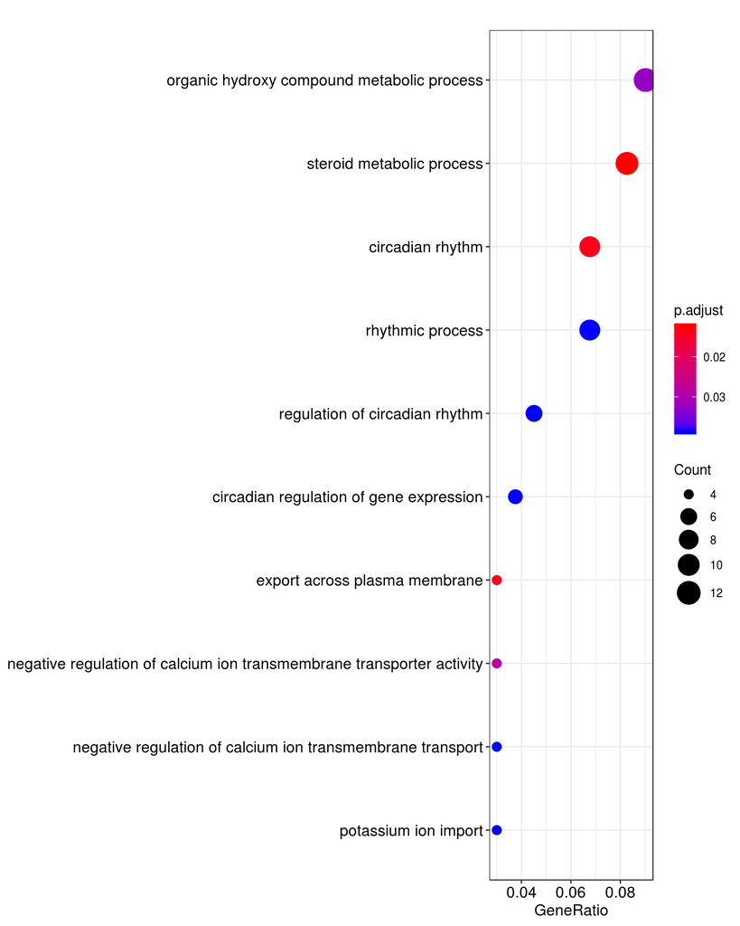

```r
> dotplot(enrich_go, showCategory = 25)
```

## GO terms map

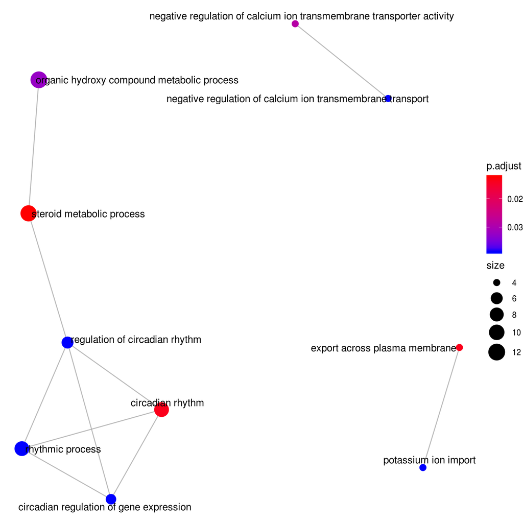

```r
> emapplot(enrich_go, showCategory = 25)
```

## Gene map

In order to consider the potentially biological complexities in which a gene may belong to multiple annotation categories, and provide information of numeric changes if available.

Here we are plotting genes colored by LFC for top 5 most significant [GO](http://www.geneontology.org) terms.

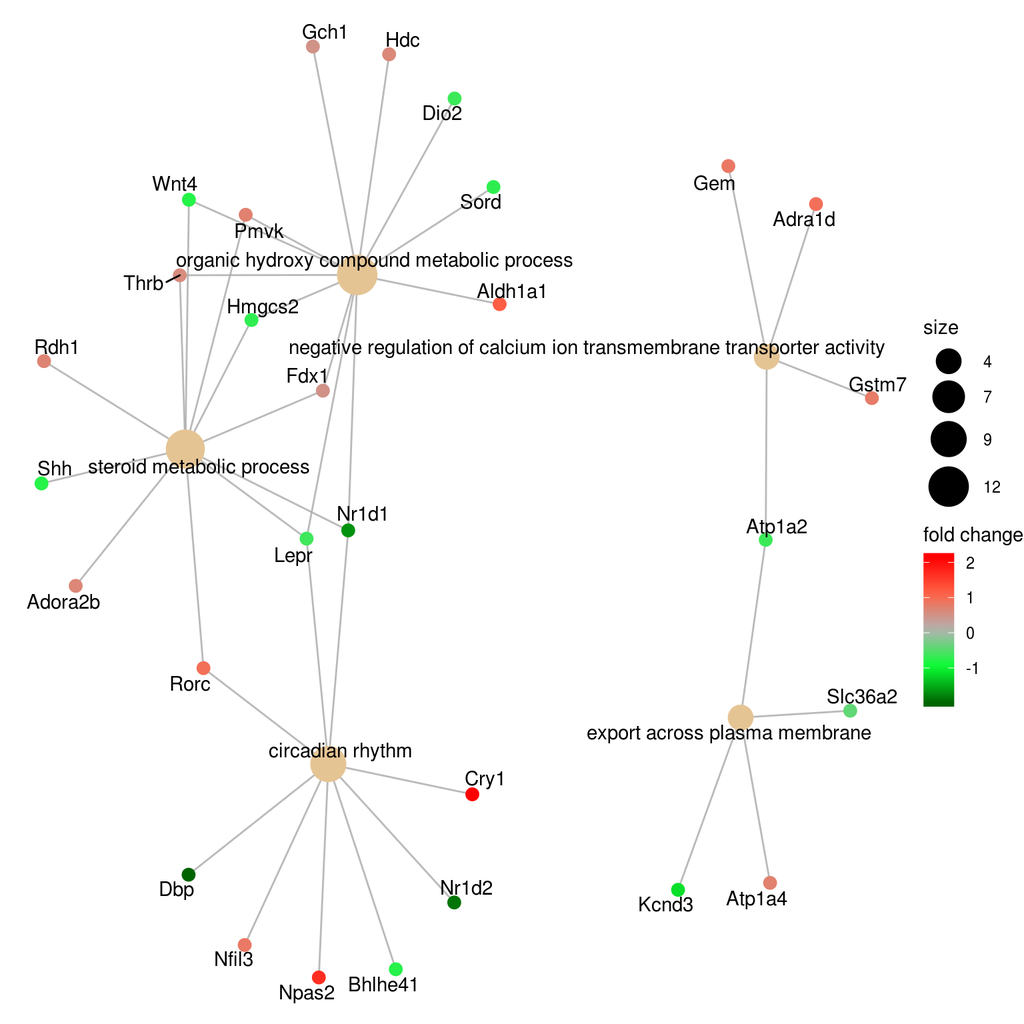

```r
> cnetplot(enrich_go, foldChange = lfc_vec)
```

## GO GSEA analysis

A common approach in analyzing gene expression profiles was identifying differential expressed genes that are deemed interesting. The enrichment analysis we demonstrated previously were based on these differentially expressed genes. This approach will find genes where the difference is large, but it will not detect a situation where the difference is small, but evidenced in coordinated way in a set of related genes. [Gene Set Enrichment Analysis (GSEA)](http://software.broadinstitute.org/gsea) directly addresses this limitation. All genes can be used in [GSEA](http://software.broadinstitute.org/gsea); [GSEA](http://software.broadinstitute.org/gsea) aggregates the per gene statistics across genes within a gene set, therefore making it possible to detect situations where all genes in a predefined set change in a small but coordinated way. Since it is likely that many relevant phenotypic differences are manifested by small but consistent changes in a set of genes.

```r
> # Prepare the gene list.
> # Here we're subtracting the adjusted P value from 1.
> gene_list <- 1 - res_df$padj
> names(gene_list) <- row.names(res_df)
> gene_list <- sort(gene_list, decreasing = TRUE)
> glimpse(gene_list)
```

```
##  Named num [1:18464] 1 1 1 1 1 1 1 1 1 1 ...
##  - attr(*, "names")= chr [1:18464] "ENSMUSG00000020038" "ENSMUSG00000020889" "ENSMUSG00000021775" "ENSMUSG00000026077" ...
```

```r
> # Now run GSEA
> # help("gseGO", "clusterProfiler")
> # minGSSize = 100
> gsea_go <- gseGO(
+     geneList = gene_list,
+     ont = params$go_class,
+     OrgDb = org_db,
+     keyType = "ENSEMBL",
+     pvalueCutoff = 0.05
+ )
```

```
## preparing geneSet collections...
```

```
## GSEA analysis...
```

```
## no term enriched under specific pvalueCutoff...
```

```r
> gsea_go_tbl <- gsea_go %>%
+     slot("result") %>%
+     as_tibble() %>%
+     camel()
> saveData(gsea_go, gsea_go_tbl, dir = params$data_dir)
```

```
## Saving gsea_go.rda, gsea_go_tbl.rda to /home/travis/build/hbc/bcbio_rnaseq_output_example/report/data
```

```r
> write_csv(
+     gsea_go_tbl,
+     path = file.path(
+         params$results_dir,
+         paste0(
+             paste(
+                 "gsea",
+                 "clusterprofiler",
+                 "padj",
+                 alpha,
+                 "lfc",
+                 params$lfc_threshold,
+                 sep = "_"
+             ),
+             ".csv.gz"
+         )
+     )
+ )
>
> gsea_go_tbl
```

| id | description | setSize | enrichmentScore | nes | pvalue | pAdjust | qvalues |
| --- | --- | --- | --- | --- | --- | --- | --- |

# KEGG enrichment analysis

## Map gene IDs to Entrez IDs

[Entrez](https://www.ncbi.nlm.nih.gov/gquery) IDs are required for [Kyoto Encyclopedia of Genes and Genomes (KEGG)](http://www.genome.jp/kegg) analysis. Here we are defining 1:1 mappings of the [Ensembl](https://www.ensembl.org) gene IDs to [Entrez](https://www.ncbi.nlm.nih.gov/gquery) IDs. For genes that map to multiple [Entrez](https://www.ncbi.nlm.nih.gov/gquery) IDs, we are using the oldest [Entrez](https://www.ncbi.nlm.nih.gov/gquery) ID to define the 1:1 mapping.

```r
> # Define the Ensembl gene to Entrez identifier mappings
> gene2entrez <- rowData(dds)$entrezID
> stopifnot(is.list(gene2entrez))
> stopifnot(!is.null(names(gene2entrez)))
> gene2entrez <- lapply(gene2entrez, function(x) {
+     if (all(is.na(x))) {
+         NULL
+     } else {
+         # For genes that don't map 1:1 with Entrez, use the oldest Entrez ID.
+         # Also, ensure the IDs are coerced to character.
+         as.character(sort(x)[[1L]])
+     }
+ })
> # Drop genes that don't match to Entrez
> gene2entrez <- Filter(Negate(is.null), gene2entrez)
> # Ensembl gene IDs are names; Entrez gene ID are values
> gene2entrez <- unlist(gene2entrez)
> glimpse(gene2entrez)
```

```
##  Named chr [1:14754] "14679" "12544" "107815" "67608" "12390" "23849" ...
##  - attr(*, "names")= chr [1:14754] "ENSMUSG00000000001" "ENSMUSG00000000028" "ENSMUSG00000000037" "ENSMUSG00000000056" ...
```

```r
> saveData(gene2entrez, dir = params$data_dir)
```

```
## Saving gene2entrez.rda to /home/travis/build/hbc/bcbio_rnaseq_output_example/report/data
```

Now let’s get the background of unique Entrez IDs.

```r
> # Unique Entrez IDs to use for background
> all_entrez <- gene2entrez %>%
+     unique() %>%
+     as.integer() %>%
+     sort() %>%
+     as.character()
> glimpse(all_entrez)
```

```
##  chr [1:14737] "11302" "11303" "11304" "11305" "11306" "11307" "11308" ...
```

Now we need to map the DESeqResults values to our Entrez IDs. Let’s obtain a vector of significant genes that map to Entrez.

```r
> # Significant genes that map to Entrez ID (which can be duplicated)
> sig_gene2entrez <- gene2entrez[intersect(sig_genes, names(gene2entrez))]
> glimpse(sig_gene2entrez)
```

```
##  Named chr [1:136] "209387" "76681" "13107" "12952" "72701" "13170" ...
##  - attr(*, "names")= chr [1:136] "ENSMUSG00000057596" "ENSMUSG00000066258" "ENSMUSG00000052974" "ENSMUSG00000020038" ...
```

```r
> # any(duplicated(sig_gene2entrez))
```

```r
> stopifnot(all(names(sig_gene2entrez) %in% rownames(res_df)))
>
> # Filter to contain only significant genes that map to Entrez
> sig_entrez_res_df <- res_df %>%
+     .[names(sig_gene2entrez), ] %>%
+     rownames_to_column("geneID") %>%
+     mutate(entrezID = sig_gene2entrez) %>%
+     group_by(entrezID) %>%
+     # Get the most significant result, per Entrez ID
+     top_n(n = 1, wt = padj) %>%
+     as.data.frame() %>%
+     set_rownames(.$entrezID)
> saveData(sig_entrez_res_df, dir = params$data_dir)
```

```
## Saving sig_entrez_res_df.rda to /home/travis/build/hbc/bcbio_rnaseq_output_example/report/data
```

```r
> sig_entrez <- pull(sig_entrez_res_df, entrezID)
>
> # Extract the fold changes
> entrez_lfc_vec <- sig_entrez_res_df$log2FoldChange
> names(entrez_lfc_vec) <- sig_entrez_res_df$entrezID
> # Sort from upregulated to downregulated
> entrez_lfc_vec <- sort(entrez_lfc_vec, decreasing = TRUE)
> glimpse(entrez_lfc_vec)
```

```
##  Named num [1:136] 2.16 1.99 1.67 1.57 1.34 ...
##  - attr(*, "names")= chr [1:136] "12952" "269116" "18143" "13426" ...
```

```r
> kegg <- enrichKEGG(
+     gene = as.character(sig_entrez),
+     organism = kegg_code,
+     keyType = "ncbi-geneid",
+     universe = as.character(all_entrez),
+     qvalueCutoff = 0.05
+ )
> kegg_tbl <- kegg %>%
+     slot("result") %>%
+     as_tibble() %>%
+     camel()
> saveData(kegg, kegg_tbl, dir = params$data_dir)
```

```
## Saving kegg.rda, kegg_tbl.rda to /home/travis/build/hbc/bcbio_rnaseq_output_example/report/data
```

```r
> write_csv(
+     kegg_tbl,
+     path = file.path(
+         params$results_dir,
+         paste0(
+             paste(
+                 "kegg",
+                 "clusterprofiler",
+                 "padj",
+                 alpha,
+                 "lfc",
+                 params$lfc_threshold,
+                 sep = "_"
+             ),
+             ".csv.gz"
+         )
+     )
+ )
>
> kegg_tbl
```

|  | id | description | geneRatio | bgRatio | pvalue | pAdjust | qvalue | geneID | count |
| --- | --- | --- | --- | --- | --- | --- | --- | --- | --- |
| 1 | mmu04710 | Circadian rhythm | 5/73 | 29/5703 | 2.797388e-05 | 0.004979351 | 0.004770283 | 12952/217166/18143/19885/79362 | 5 |
| 2 | mmu00980 | Metabolism of xenobiotics by cytochrome P450 | 4/73 | 43/5703 | 2.091311e-03 | 0.186126660 | 0.178311762 | 13107/68312/103140/76263 | 4 |
| 3 | mmu04973 | Carbohydrate digestion and absorption | 3/73 | 31/5703 | 6.995116e-03 | 0.370750551 | 0.355183852 | 15277/27222/98660 | 3 |
| 4 | mmu04970 | Salivary secretion | 4/73 | 63/5703 | 8.331473e-03 | 0.370750551 | 0.355183852 | 11550/27222/320707/98660 | 4 |
| 5 | mmu04919 | Thyroid hormone signaling pathway | 5/73 | 110/5703 | 1.294208e-02 | 0.429333487 | 0.411307066 | 22417/27222/98660/13371/21834 | 5 |
| 6 | mmu00982 | Drug metabolism - cytochrome P450 | 3/73 | 42/5703 | 1.616387e-02 | 0.429333487 | 0.411307066 | 68312/103140/76263 | 3 |
| 7 | mmu04964 | Proximal tubule bicarbonate reclamation | 2/73 | 18/5703 | 2.166142e-02 | 0.429333487 | 0.411307066 | 27222/98660 | 2 |
| 8 | mmu05204 | Chemical carcinogenesis | 3/73 | 48/5703 | 2.306504e-02 | 0.429333487 | 0.411307066 | 68312/103140/76263 | 3 |
| 9 | mmu04925 | Aldosterone synthesis and secretion | 4/73 | 91/5703 | 2.863710e-02 | 0.429333487 | 0.411307066 | 27222/320707/98660/16527 | 4 |
| 10 | mmu00900 | Terpenoid backbone biosynthesis | 2/73 | 21/5703 | 2.900852e-02 | 0.429333487 | 0.411307066 | 68603/15360 | 2 |

[output cut: 168 more lines]

## KEGG GSEA analysis

[GSEA](http://software.broadinstitute.org/gsea) analysis is performed with the clusterProfiler tool using KEGG gene sets and using the log2 fold changes as input. By using the log2 fold changes as the input, we are identifying pathways with genes that exhibit coordinated fold changes that are larger than might be expected by chance. The significant pathways can be visualized using the log2 fold changes with the Pathview tool.

Gene set enrichment analysis tools use ranked lists of genes (here ranked by log2FC) without using a threshold. This allows the tools to use more information to identify enriched biological processes. The [introduction to gene set enrichment analysis](http://www.ncbi.nlm.nih.gov/pmc/articles/PMC1239896) goes into more detail about some of the advantages of this approach. By using the log2 fold changes as the input, we are identifying pathways with genes that exhibit coordinated fold changes that are larger than might be expected by chance. The significant pathways can be visualized using the log2 fold changes with the pathview tool.

When performing [GSEA](http://software.broadinstitute.org/gsea) analysis it may be useful to adjust the minGSSize and/or maxGSSize parameter based on the pathways you would like to search for significance. If you are interested in smaller pathways, such as phototransduction, which has a gene set size of 24 genes, then you would want to adjust the minGSSize to less than 24. If you are only interested in larger pathways, then you would want to adjust the GSSize to a larger number. The fewer pathways tested, the less we need to correct for multiple test correction, so by adjusting the minGSSize and maxGSSize parameters you can test fewer pathways and limit testing to the pathways of interest.

```r
> gsea_kegg <- gseKEGG(
+     geneList = entrez_lfc_vec,
+     organism = kegg_code,
+     keyType = "ncbi-geneid"
+ )
```

```
## preparing geneSet collections...
```

```
## GSEA analysis...
```

```
## no term enriched under specific pvalueCutoff...
```

```r
> gsea_kegg_tbl <- gsea_kegg %>%
+     slot("result") %>%
+     as_tibble() %>%
+     camel()
> saveData(gsea_kegg, dir = params$data_dir)
```

```
## Saving gsea_kegg.rda to /home/travis/build/hbc/bcbio_rnaseq_output_example/report/data
```

```r
> write_csv(
+     gsea_kegg_tbl,
+     path = file.path(
+         params$results_dir,
+         paste0(
+             paste(
+                 "gsea",
+                 "kegg",
+                 "clusterprofiler",
+                 "padj",
+                 alpha,
+                 "lfc",
+                 params$lfc_threshold,
+                 sep = "_"
+             ),
+             ".csv.gz"
+         )
+     )
+ )
>
> gsea_kegg_tbl
```

| id | description | setSize | enrichmentScore | nes | pvalue | pAdjust | qvalues |
| --- | --- | --- | --- | --- | --- | --- | --- |

```r
> # help("pathview", "pathview")
> #
> # There is currently no way to set the output path of the pathview PNG files, so
> # we're changing the working directory. Generally this is not recommended!
> #
> # Also, We're using `tryCatch()` here to return to the user any pathways that
> # didn't output graphics correctly.
> pathways <- gsea_kegg_tbl$id
> if (length(pathways)) {
+     # dplyr must be unloaded for pathview to work
+     suppressWarnings(detach("package:dplyr", unload = TRUE, force = TRUE))
+     wd <- getwd()
+     setwd(kegg_plots_dir)
+     invisible(lapply(pathways, function(pathway) {
+         # `gene.data` vector should be numeric with Entrez IDs as names
+         tryCatch(
+             pathview(
+                 gene.data = entrez_lfc_vec,
+                 pathway.id = pathway,
+                 species = kegg_code,
+                 limit = list(gene = 2, cpd = 1)
+             ),
+             error = function(e) {
+                 # Return a warning instead of an error
+                 warning(paste(pathway, "failed to plot"), call. = FALSE)
+             }
+         )
+     }))
+     setwd(wd)
+     figures <- list.files(
+         path = kegg_plots_dir,
+         pattern = "pathview",
+         full.names = TRUE
+     )
+     invisible(lapply(figures, function(figure) {
+         cat(paste0("<img src=\"", figure, "\">\n"))
+     }))
+ }
```

# Methods

# R session information

```r
> markdownHeader("YAML params", level = 2)
```

## YAML params

```r
> print(params)
```

```
## $go_class
## [1] "BP"
##
## $lfc_threshold
## [1] 0
##
## $results_dir
## [1] "results/2018-07-18/functional_analysis"
##
## $dds_file
## [1] "data/dds.rda"
##
## $res_file
## [1] "data/res.rda"
##
## $organism
## [1] "Mus musculus"
##
## $data_dir
## [1] "data"
```

```r
> markdownHeader("`_setup.R`", level = 2)
```

## `_setup.R`

```r
> readr::read_lines("_setup.R") %>% writeLines()
```

```
## library(bcbioRNASeq)
## library(DESeq2)
## library(DEGreport)
## library(knitr)
## library(tidyverse)
##
## # Set seed for reproducibility
## set.seed(1454944673L)
##
## opts_chunk[["set"]](
##     autodep = TRUE,
##     bootstrap.show.code = FALSE,
##     cache = TRUE,
##     cache.lazy = TRUE,
##     dev = c("png", "pdf"),
##     fig.height = 10L,
##     fig.retina = 2L,
##     fig.width = 10L,
##     highlight = TRUE,
##     prompt = TRUE,
##     tidy = FALSE
## )
##
## theme_set(
##     theme_paperwhite(
##         base_size = 14L,
##         legend_position = "right"
##     )
## )
```

```r
> markdownHeader("`sessioninfo::session_info()`", level = 2)
> markdownHeader("`utils::sessionInfo()`", level = 2)
```

[output not shown]

Kolde, Raivo. 2015. *Pheatmap: Pretty Heatmaps*. https://CRAN.R-project.org/package=pheatmap.

Love, Michael I, Wolfgang Huber, and Simon Anders. 2014. “Moderated Estimation of Fold Change and Dispersion for RNA-seq Data with DESeq2.” *Genome Biol.* 15 (12): 550. https://doi.org/10.1186/s13059-014-0550-8.

Patro, Rob, Geet Duggal, Michael I Love, Rafael A Irizarry, and Carl Kingsford. 2017. “Salmon Provides Fast and Bias-Aware Quantification of Transcript Expression.” *Nat. Methods* 14 (4): 417–19. https://doi.org/10.1038/nmeth.4197.

Soneson, Charlotte, Michael I Love, and Mark D Robinson. 2016. “Differential Analyses for RNA-seq: Transcript-Level Estimates Improve Gene-Level Inferences.” *F1000Res.* 4 (December). https://doi.org/10.12688/f1000research.7563.1.

Wickham, Hadley. 2009. *Ggplot2: Elegant Graphics for Data Analysis*. Use R. Springer New York. https://doi.org/10.1007/978-0-387-98141-3.